# analyseAll

Alex Holcombe

7/28/2018

Load ggplot and dplyr

## Proportion correct

One target. Why when rightResponseFirst == True, almost always scored as incorrect, correct0 = 0? (indicating subject got it wrong?). Probably didn’t match the response0 to the correct stimulus, instead still matched it to the letter on the left/top. And unfortunately didn’t record the letter/word on the other side. To fix, have to write python script to rerun the code with the same seed to find out what letters they were, and then integrate with my tibble. Jesus.

```
## # A tibble: 2 x 3
##   rightResponseFirst correct0 correct1
##   <chr>                 <dbl>    <dbl>
## 1 False                0.727       -99
## 2 True                 0.0462      -99
```

Two targets

```
## # A tibble: 1 x 2
##   correct0 correct1
##      <dbl>    <dbl>
## 1    0.635    0.721
```

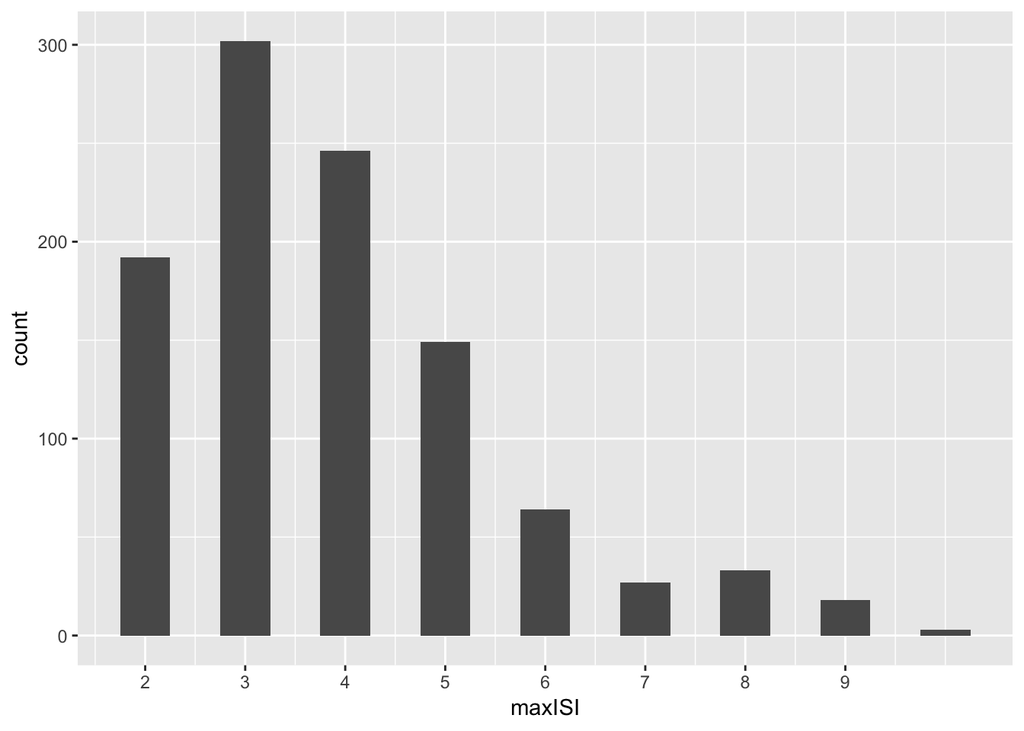

```r
#Inspect what ISIframes got up to

maxPossibleISIframes <- 9
maxEachSubject<- tb %>% filter(practice==0) %>% group_by(subject) %>% summarise(maxISI = max(ISIframes))
#Determine subject numbers who maxxed out
maxedOut <- unique(  tb %>% filter(ISIframes == maxPossibleISIframes)   )
ggplot(maxEachSubject, aes(x=maxISI)) + geom_histogram(binwidth=.5) +scale_x_continuous(breaks=seq(2,9))
```

```r
#Exclusion criteria
correctExclusionThreshold <- .4
#Exclude trials with one target, three targets
tbTwo <- tb %>% filter(oneTarget == "False", numSimultaneousStim < 3)
#correct0 refers to left, correct1 to right.
overall<- tbTwo %>% group_by(subject) %>% summarise_at(c("correct0","correct1"),mean)
overall <- overall %>% mutate(pCorr = (correct0 + correct1)/2)
tooLow2 <- overall %>% filter(pCorr < correctExclusionThreshold)
cat("subjects who were too low in two-target condition are:")
```

```
## subjects who were too low in two-target condition are:
```

```r
tooLow2
```

```
## # A tibble: 22 x 4
##    subject correct0 correct1  pCorr
##    <chr>      <dbl>    <dbl>  <dbl>
##  1 1014      0.158    0.632  0.395
##  2 102       0.0440   0.0503 0.0472
##  3 112       0.152    0.576  0.364
##  4 219       0.405    0.378  0.392
##  5 232       0.0833   0.417  0.25
##  6 400       0.185    0.308  0.246
##  7 432       0.413    0.253  0.333
##  8 442       0        0.05   0.025
##  9 451       0.429    0.362  0.396
## 10 49        0.0952   0.524  0.310
## # … with 12 more rows
```

```r
#Exclude low performers in the 3-target condition
tbThree <- tb %>% filter(numSimultaneousStim == 3)
overall<- tbThree %>% group_by(subject) %>% summarise_at(c("correct0","correct1","correct2"),mean)
overall <- overall %>% mutate(pCorr = (correct0 + correct1 + correct2)/3)
tooLow3 <- overall %>% filter(pCorr < correctExclusionThreshold)
cat("subjects who were too low in three-target condition are:")
```

```
## subjects who were too low in three-target condition are:
```

```r
tooLow3
```

```
## # A tibble: 2 x 5
##   subject correct0 correct1 correct2 pCorr
##   <chr>      <dbl>    <dbl>    <dbl> <dbl>
## 1 1011       0.449    0.382    0.360 0.397
## 2 515        0.448    0.375    0.344 0.389
```

```r
#Compare response0 to
#
```

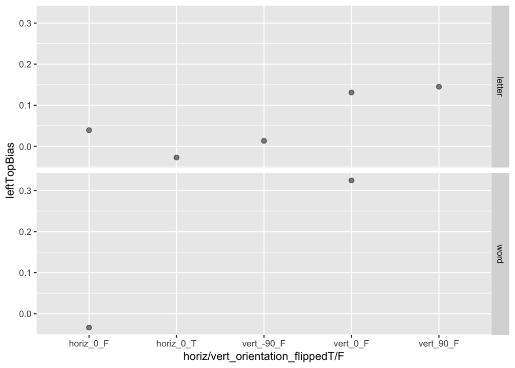

```r
#Group by condition, which is defined by spatial,stimType,flipped,orient
#table(tbTwo$spatial,tbTwo$flipped,tbTwo$ori,tbTwo$stimType)
#Then plot difference between correct0 and correct1. One way to get difference is subtract correct1 from correct0 and average
#tbTwo$leftBtmBias <- tbTwo$correct0-tbTwo$correct1


tbTwo <- tbTwo %>% mutate(flippedTemp = substr(flipped,1,1)) #reduce to first letter only
tbTwo <- tbTwo %>% mutate(cond = paste(stimType, spatial, ori, flipped, sep = '_'))
tbTwo <- tbTwo %>% mutate(condExceptStim = paste(spatial, ori, flippedTemp, sep = '_'))
gg<- ggplot(tbTwo, aes(x=condExceptStim,y=leftTopBias)) + stat_summary(fun.y="mean",geom="point",size=2, alpha=.5) + facet_grid(stimType~.)
#xondition name is paste(numSimultaneousStim, stimType, spatial, ori, flipped, sep = '_'))
gg<- gg + xlab("horiz/vert_orientation_flippedT/F")
gg<- gg+ stat_summary(fun.data="mean_cl_boot",fun.args=list(conf.int=0.95),geom="errorbar",width=.3,size=1)
show(gg)
```

```r
wordsByS <- tbTwo %>% filter(stimType=="word") %>% group_by(subject,spatial) %>% summarise_at(c("correct0","correct1"),mean)
wordsByCond<- wordsByS %>% group_by(spatial)  %>% summarise_all(mean)
wordsByCond
```

```
## # A tibble: 2 x 4
##   spatial subject correct0 correct1
##   <chr>     <dbl>    <dbl>    <dbl>
## 1 horiz        NA    0.661    0.707
## 2 vert         NA    0.376    0.709
```

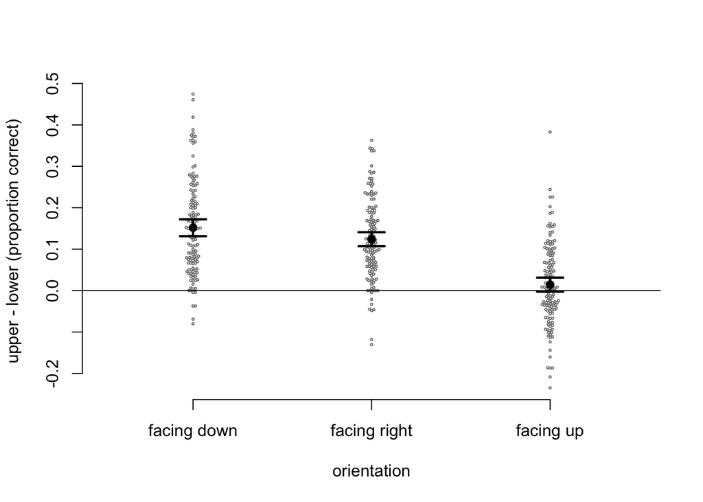

```r
ltrs2 <- tbTwo %>% filter(stimType=="letter")
# gg<- ggplot(ltrs2, aes(x=condExceptStim,y=leftTopBias)) + stat_summary(fun.y="mean",geom="point",size=2, alpha=.5) + facet_grid(.~canonical)
# gg<- gg+ stat_summary(fun.data="mean_cl_boot",fun.args=list(conf.int=0.95),geom="errorbar",width=.3,size=1)
# show(gg)

ltrs2<- ltrs2 %>% mutate(cond = case_when(condExceptStim == "vert_-90_F" ~ "facing up",
                                        condExceptStim == "vert_90_F" ~ "facing down",
                                        condExceptStim == "vert_0_F" ~ "facing right",
                                          TRUE ~ "unknown"   )) #e
# gg<- ggplot(rotated, aes(x=condExceptStim,y=leftTopBias)) + stat_summary(fun.y="mean",geom="point",size=2, alpha=.5) + stat_summary(fun.data="mean_cl_boot",fun.args=list(conf.int=0.95),geom="errorbar",width=.3,size=1)
# show(gg)


vert<- ltrs2 %>% filter(spatial=="vert")
library('beeswarm')
papaja::apa_beeplot(data=vert, id="subject", dv="leftTopBias", factors="cond",
                    ylab = "upper - lower (proportion correct)", xlab = "orientation",
                    args_points = list(cex = 1, bg = c("black"),col="black"),
                    args_swarm = list(cex = .3, bg = c("white"),col="grey50"),
                    , args_error_bars = list(lwd=2.2,length = 0.13))
abline(h=0)
```

```r
#apa_print() output looks horrible unless knit into PDF or Word as part of a papaja document
#papaja::apa_print(t_vert)

# rotatedOnly <- ltrs2 %>% filter(canonical==FALSE)
# papaja::apa_beeplot(data=rotatedOnly, id="subject", dv="leftTopBias", factors="cond",
#                     ylab = "upper - lower (proportion correct)", xlab = "orientation",
#                     args_points = list(cex = 1, bg = c("black"),col="black"),
#                     args_swarm = list(cex = .3, bg = c("white"),col="grey50"),
#                     , args_error_bars = list(lwd=2.2,length = 0.13))
# abline(h=0)
```

Report number of Ss per condition

```r
trialsPerCondSubj <- vert %>% count(cond,subject)
subjPerCond <- trialsPerCondSubj %>% count(cond)
print(subjPerCond)
```

```
## # A tibble: 3 x 2
##   cond             n
##   <chr>        <int>
## 1 facing down    129
## 2 facing right   130
## 3 facing up      134
```

Above the effect of the orientation manipulation was pretty big, but the baseline bias (upper bias) is bigger than the left bias seen in the other plot.

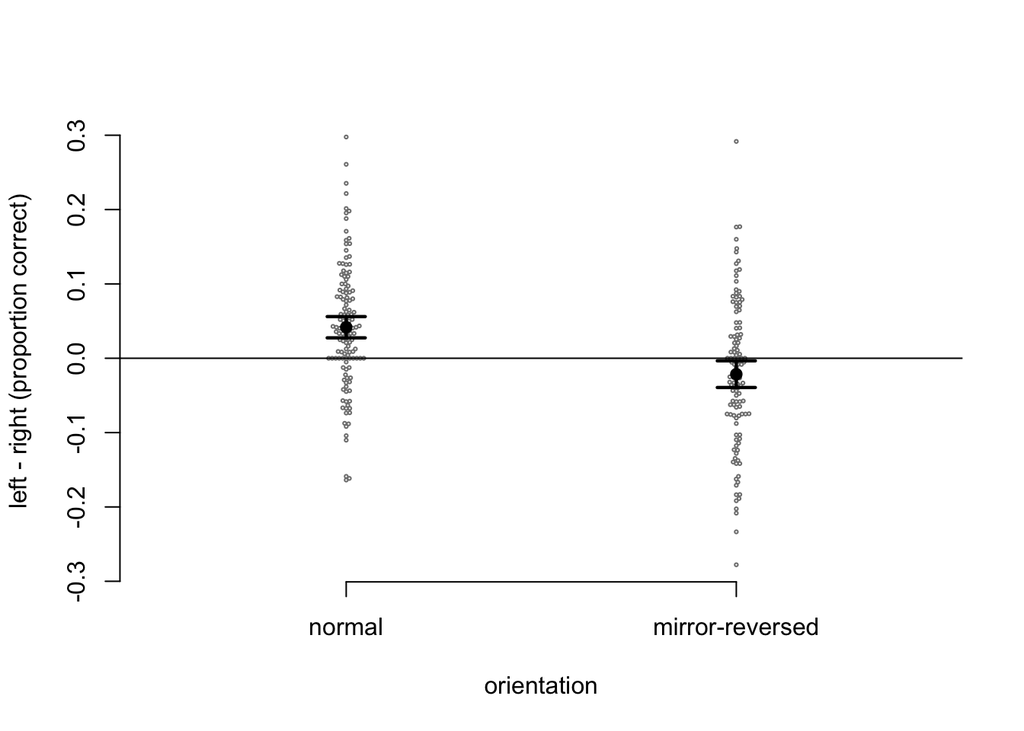

```r
horiz <- ltrs2 %>% filter(spatial=="horiz")
horiz<- horiz %>% mutate(cond = case_when(condExceptStim == "horiz_0_F" ~ "normal",
                                        condExceptStim == "horiz_0_T" ~ "mirror-reversed",
                                          TRUE ~ "unknown"   ))
#change order so normal appears first on plot
horiz$cond <- as.factor(horiz$cond)
horiz <- transform(horiz, cond=reorder(cond, flipped) )  #https://stackoverflow.com/a/3744432/302378
papaja::apa_beeplot(data=horiz, id="subject", dv="leftTopBias", factors="cond",
                    ylab = "left - right (proportion correct)", xlab = "orientation",
                    args_points = list(cex = 1, bg = c("black"),col="black"),
                    args_swarm = list(cex = .3, bg = c("white"),col="grey50"),
                    , args_error_bars = list(lwd=2.2,length = 0.13))
abline(h=0)
```

Number of Ss per condition

```r
trialsPerCondSubj <- horiz %>% count(cond,subject)
subjPerCond <- trialsPerCondSubj %>% count(cond)
print(subjPerCond)
```

```
## # A tibble: 2 x 2
##   cond                n
##   <fct>           <int>
## 1 normal            132
## 2 mirror-reversed   118
```

The horizontal t-test results are

```r
t_horiz <- t.test(
  x = (horiz %>% filter(cond == "normal"))$leftTopBias
  , y = (horiz %>% filter(cond == "mirror-reversed"))$leftTopBias
  , paired = FALSE
)

t_horiz
```

```
##
##  Welch Two Sample t-test
##
## data:  (horiz %>% filter(cond == "normal"))$leftTopBias and (horiz %>% filter(cond == "mirror-reversed"))$leftTopBias
## t = 13.326, df = 40670, p-value < 2.2e-16
## alternative hypothesis: true difference in means is not equal to 0
## 95 percent confidence interval:
##  0.05667803 0.07622585
## sample estimates:
##   mean of x   mean of y
##  0.03926413 -0.02718781
```

```r
# Let's see what the apa_print() output looks like
#papaja::apa_print(t_horiz)
```

For horizontal configuration, the normal and mirror-reversed orientation results with upper and lower confidence intervals are:

```r
#install.packages("Rmisc")
library(Rmisc)
horiz %>% group_by(cond) %>% summarise(upperCI = CI(leftTopBias)[1], mean=mean(leftTopBias), lower= CI(leftTopBias)[3])
```

```
## # A tibble: 2 x 4
##   cond            upperCI    mean   lower
##   <fct>             <dbl>   <dbl>   <dbl>
## 1 normal           0.0455  0.0393  0.0330
## 2 mirror-reversed -0.0197 -0.0272 -0.0347
```

For Caleb PSYC1, calculate accuracy per condition, not just bias

```r
horizEachS<- horiz %>% group_by(cond,subject) %>% summarise_at(.vars = c("correct0","correct1"),
                 .funs = c(mean="mean"))
horizEachCond<- horizEachS %>%  group_by(cond) %>% summarise_all(funs(mean))
vertEachS<- vert %>% group_by(cond,subject) %>% summarise_at(.vars = c("correct0","correct1"),
                 .funs = c(mean="mean"))
vertEachCond<- vertEachS %>%  group_by(cond) %>% summarise_all(funs(mean))
t_horiz <- t.test(
  x = (horizEachS %>% filter(cond == "mirror-reversed"))$correct0_mean
  , y = (horiz %>% filter(cond == "mirror-reversed"))$correct1_mean
  , paired = FALSE
)
t_horiz
```

```
##
##  One Sample t-test
##
## data:  (horizEachS %>% filter(cond == "mirror-reversed"))$correct0_mean
## t = 66.868, df = 117, p-value < 2.2e-16
## alternative hypothesis: true mean is not equal to 0
## 95 percent confidence interval:
##  0.6555790 0.6955973
## sample estimates:
## mean of x
## 0.6755882
```

```r
t_vert <- t.test(
  x = (vert %>% filter(cond == "facing down"))$leftTopBias
  , y = (vert %>% filter(cond == "facing up"))$leftTopBias
  , paired = FALSE
)
t_vert
```

```
##
##  Welch Two Sample t-test
##
## data:  (vert %>% filter(cond == "facing down"))$leftTopBias and (vert %>% filter(cond == "facing up"))$leftTopBias
## t = 25.278, df = 44489, p-value < 2.2e-16
## alternative hypothesis: true difference in means is not equal to 0
## 95 percent confidence interval:
##  0.1215882 0.1420286
## sample estimates:
##  mean of x  mean of y
## 0.14512904 0.01332065
```

```r
vert %>% group_by(cond) %>% summarise(upperCI = CI(leftTopBias)[1], mean=mean(leftTopBias), lower= CI(leftTopBias)[3])
```

```
## # A tibble: 3 x 4
##   cond         upperCI   mean   lower
##   <chr>          <dbl>  <dbl>   <dbl>
## 1 facing down   0.152  0.145  0.138
## 2 facing right  0.138  0.131  0.124
## 3 facing up     0.0205 0.0133 0.00616
```

Correlate the bias of each participant with their author score.

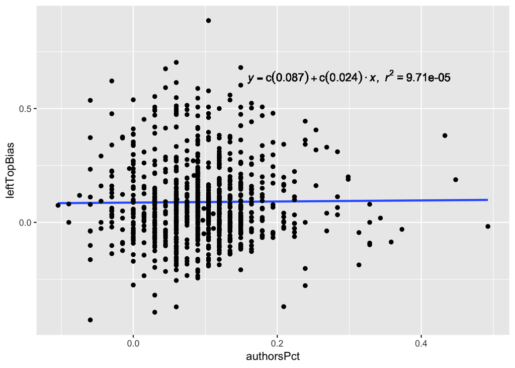

```r
#install.packages('ggstatsplot')  #doesn't work
#Probably need to reduce the dataframe to one data point per subject
tbTwoSumm <- tbTwo %>% group_by(subject) %>% summarise_at(c("leftTopBias", "authorsPct", "authorsRaw", "authorsTotalChosen"),mean)
hh<- ggplot(tbTwoSumm, aes(y=leftTopBias, x=authorsPct)) + geom_point() +   geom_smooth(method="lm",se=FALSE) +
  geom_point()

lm_eqn = function(m) {

  l <- list(a = format(coef(m)[1], digits = 2),
      b = format(abs(coef(m)[2]), digits = 2),
      r2 = format(summary(m)$r.squared, digits = 3));

  if (coef(m)[2] >= 0)  {
    eq <- substitute(italic(y) == a + b %.% italic(x)*","~~italic(r)^2~"="~r2,l)
  } else {
    eq <- substitute(italic(y) == a - b %.% italic(x)*","~~italic(r)^2~"="~r2,l)
  }

  as.character(as.expression(eq));
}
hh = hh + geom_text(aes(x = .3, y = .64, label = lm_eqn(lm(leftTopBias ~ authorsPct, tbTwoSumm))), parse = TRUE)
hh
```

```r
#cor.test(
```

change MEAN ABOVE TO INCLUDE FIRST LANGUAGE READ AND TAKES FIRST INSTNACE IF NOT NUMERIC Look at first language read. ```